# Clasificación con KNN y SMOTE

En este notebook construimos, paso a paso, una solución de aprendizaje de máquina, siguiendo el mismo ciclo de trabajo que ya usaste en prácticas anteriores (comprensión del problema, comprensión y preparación de los datos, modelado y evaluación) para un problema sobre predecir si un vino será calificado como de buena calidad a partir de sus propiedades físico-químicas.

Usaremos este caso para ver en acción dos técnicas: **K-Nearest Neighbors (KNN)**, un clasificador que decide la clase de una observación nueva a partir de sus vecinos más cercanos, y **SMOTE (Synthetic Minority Over-sampling Technique)**, una técnica para mejorar el desbalance de clases, generando ejemplos sintéticos de la clase minoritaria.

El flujo general es el siguiente:

1. Importar librerías
2. Comprensión del problema
3. Comprensión de los datos
4. Limpieza y preparación de los datos
5. Modelado con KNN, sin y con SMOTE
6. Evaluación
7. Cierre.
8. Ejercicios

## 1. Importar librerías

```python
import numpy as np
import pandas as pd
import matplotlib.pyplot as plt

from sklearn.model_selection import train_test_split, StratifiedKFold, GridSearchCV
from sklearn.pipeline import Pipeline
from sklearn.preprocessing import StandardScaler
from sklearn.neighbors import KNeighborsClassifier
from sklearn.metrics import classification_report, confusion_matrix, ConfusionMatrixDisplay, f1_score, recall_score, precision_score

from imblearn.pipeline import Pipeline as ImbPipeline
from imblearn.over_sampling import SMOTE
```

## 2. Comprensión del problema

Evaluar la calidad de un vino tradicionalmente depende de catadores expertos, un proceso costoso, lento y hasta cierto punto subjetivo. Si pudiéramos predecir con buena precisión la calidad de un vino a partir de mediciones físico-químicas objetivas (acidez, azúcar, alcohol, etc.), una bodega podría usar ese modelo como un filtro de control de calidad rápido y barato, reservando la cata experta para los casos más dudosos.

## 3. Comprensión de los datos

Cargamos el conjunto de vino tinto directamente desde el UCI Machine Learning Repository. Dataset: Cortez, P., Cerdeira, A., Almeida, F., Matos, T., & Reis, J. (2009). Modeling wine preferences by data mining from physicochemical properties. Decision Support Systems, 47(4), 547–553. Disponible en el UCI Machine Learning Repository.

```python
url = "https://archive.ics.uci.edu/ml/machine-learning-databases/wine-quality/winequality-red.csv"
df = pd.read_csv(url, sep=';')
df.head()
```

|  | fixed acidity | volatile acidity | citric acid | residual sugar | chlorides | free sulfur dioxide | total sulfur dioxide | density | pH | sulphates | alcohol | quality |
| --- | --- | --- | --- | --- | --- | --- | --- | --- | --- | --- | --- | --- |
| 0 | 7.4 | 0.70 | 0.00 | 1.9 | 0.076 | 11.0 | 34.0 | 0.9978 | 3.51 | 0.56 | 9.4 | 5 |
| 1 | 7.8 | 0.88 | 0.00 | 2.6 | 0.098 | 25.0 | 67.0 | 0.9968 | 3.20 | 0.68 | 9.8 | 5 |
| 2 | 7.8 | 0.76 | 0.04 | 2.3 | 0.092 | 15.0 | 54.0 | 0.9970 | 3.26 | 0.65 | 9.8 | 5 |
| 3 | 11.2 | 0.28 | 0.56 | 1.9 | 0.075 | 17.0 | 60.0 | 0.9980 | 3.16 | 0.58 | 9.8 | 6 |
| 4 | 7.4 | 0.70 | 0.00 | 1.9 | 0.076 | 11.0 | 34.0 | 0.9978 | 3.51 | 0.56 | 9.4 | 5 |

```python
data = df.copy()
```

```python
data.shape
```

```
(1599, 12)
```

A continuación, el diccionario de datos completo.

#### Diccionario de datos

| Variable | Tipo | Descripción |
| --- | --- | --- |
| `fixed acidity` | Numérica (continua) | Ácidos no volátiles (principalmente tartárico) que no se evaporan fácilmente, en g/dm³ |
| `volatile acidity` | Numérica (continua) | Ácidos volátiles (principalmente acético) en g/dm³; en niveles altos genera un sabor a vinagre desagradable |
| `citric acid` | Numérica (continua) | Aporta frescura y sabor al vino, en g/dm³; se encuentra en pequeñas cantidades |
| `residual sugar` | Numérica (continua) | Azúcar remanente después de la fermentación, en g/dm³ |
| `chlorides` | Numérica (continua) | Cantidad de sal en el vino, en g/dm³ |
| `free sulfur dioxide` | Numérica (continua) | Forma libre de SO₂ en mg/dm³; previene el crecimiento microbiano y la oxidación |
| `total sulfur dioxide` | Numérica (continua) | Suma de SO₂ libre y ligado en mg/dm³; en concentraciones altas es perceptible en el sabor y olor |
| `density` | Numérica (continua) | Densidad del vino en g/cm³, relacionada con el contenido de alcohol y azúcar |
| `pH` | Numérica (continua) | Nivel de acidez/alcalinidad, en una escala de 0 (muy ácido) a 14 (muy básico) |
| `sulphates` | Numérica (continua) | Aditivo (sulfato de potasio) en g/dm³ que contribuye a los niveles de SO₂; actúa como antimicrobiano y antioxidante |
| `alcohol` | Numérica (continua) | Porcentaje de contenido de alcohol (% vol.) |
| `quality` | Numérica (discreta, ordinal) | **Variable objetivo.** Mediana de al menos 3 evaluaciones sensoriales de catadores expertos, en una escala de 0 a 10 |

El conjunto tiene 1,599 vinos y 11 variables físico-químicas, más la variable objetivo `quality`.

#### 3.1 Conociendo más la variable objetivo: ¿Qué es un vino bueno?

`quality` es un puntaje ordinal. Para plantear un problema de clasificación binaria, se adopta un criterio frecuente en la literatura sobre este conjunto de datos, donde un vino se considera bueno si quality >= 7 y no bueno en caso contrario. Este umbral permite distinguir los vinos con calificaciones altas y genera un desbalance de clases útil para analizar posteriormente técnicas como SMOTE.

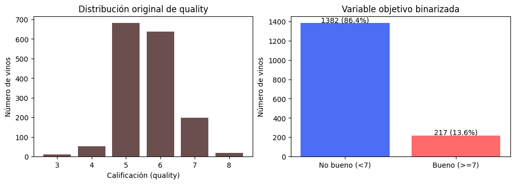

```python
fig, ax = plt.subplots(1, 2, figsize=(10, 3.5), constrained_layout=True)

conteo_quality = data['quality'].value_counts().sort_index()
ax[0].bar(conteo_quality.index.astype(str), conteo_quality.values, color='#6b4f4f')
ax[0].set(xlabel='Calificación (quality)', ylabel='Número de vinos', title='Distribución original de quality')

data['es_bueno'] = (data['quality'] >= 7).astype(int)
conteo_binaria = data['es_bueno'].value_counts().sort_index()
ax[1].bar(['No bueno (<7)', 'Bueno (>=7)'], conteo_binaria.values, color=['#4C6EF5', '#FF6B6B'])
for i, v in enumerate(conteo_binaria.values):
    ax[1].text(i, v + 10, f"{v} ({v/len(df)*100:.1f}%)", ha='center')
ax[1].set(ylabel='Número de vinos', title='Variable objetivo binarizada')

plt.show()
```

**Cómo se lee:** la mayoría de los vinos se concentran en las calificaciones intermedias (5 y 6); muy pocos llegan a 7 u 8. Al binarizar, la clase "bueno" representa solo ~13.6% de los vinos, un desbalance real (no fabricado por nosotros), consecuencia de que los catadores expertos rara vez califican un vino como sobresaliente.

#### Fuga de datos

`quality` es la fuente directa de `es_bueno`, **debe excluirse** de las variables predictoras. Las 11 variables físico-químicas restantes son las únicas variables de entrada válidas.

### 4. Limpieza y preparación de los datos.

En este conjunto de datos el único problema son las filas duplicadas (¿puedes verificar las otras dimensiones de calidad?)

```python
n_duplicados = data.duplicated().sum()
print(f"Filas exactamente duplicadas: {n_duplicados} ({n_duplicados/len(data)*100:.1f}% del total)")
```

```
Filas exactamente duplicadas: 240 (15.0% del total)
```

~15% de las filas eran duplicados exactos. Los eliminamos antes de particionar en entrenamiento y prueba, precisamente para que ninguna copia de una misma observación pueda quedar en ambos conjuntos a la vez.

```python
data = data.drop_duplicates().reset_index(drop=True)
print(f"Filas después de eliminar duplicados: {len(data)}")
```

```
Filas después de eliminar duplicados: 1359
```

Por otra parte, es importante escalar las variables para KNN al basarse en distancias. Por ejemplo, en este contexto, una variable con escala mucho mayor que las demás como `total sulfur dioxide` (que llega a cientos), frente a `citric acid` (que rara vez supera 1) dominaría el cálculo si no se realiza un escalado. Para este problema vamos a utilizar `StandardScaler`.

Por último, separamos variables predictoras y objetivo, y particionamos en entrenamiento y prueba de forma estratificada (para preservar la proporción ~86/14 en ambos conjuntos).

```python
X = data.drop(columns=['quality', 'es_bueno'])
y = data['es_bueno']

X_train, X_test, y_train, y_test = train_test_split(X, y, test_size=0.25, stratify=y, random_state=42)

print(f"Entrenamiento: {len(X_train)} vinos ({y_train.mean()*100:.1f}% buenos)")
print(f"Prueba:        {len(X_test)} vinos ({y_test.mean()*100:.1f}% buenos)")
```

```
Entrenamiento: 1019 vinos (13.5% buenos)
Prueba:        340 vinos (13.5% buenos)
```

## 5. Modelado

### 5.1 Modelado con KNN sin SMOTE

Construimos un pipeline (`StandardScaler` + `KNeighborsClassifier`) y buscamos los mejores hiperparámetros con `GridSearchCV`. El grid se limita a dos decisiones: cuántos vecinos considerar (`n_neighbors`) y qué función de distancia usar (`metric`).

```python
param_grid = {
    'knn__n_neighbors': [1, 3, 5, 7, 9, 11, 15, 21],
    'knn__metric': ['minkowski', 'manhattan'],
}

cv = StratifiedKFold(n_splits=5, shuffle=True, random_state=42)

knn_pipeline = Pipeline(steps=[
    ('scaler', StandardScaler()),
    ('knn', KNeighborsClassifier())
])

knn_grid = GridSearchCV(
    estimator=knn_pipeline,
    param_grid=param_grid,
    cv=cv,
    scoring='f1_macro',
    n_jobs=-1
)
knn_grid.fit(X_train, y_train)

print("Mejores hiperparámetros:", knn_grid.best_params_)
print(f"F1-macro en validación cruzada: {knn_grid.best_score_:.3f}")

best_knn = knn_grid.best_estimator_
```

```
Mejores hiperparámetros: {'knn__metric': 'minkowski', 'knn__n_neighbors': 3}
F1-macro en validación cruzada: 0.685
```

Optimizamos `f1_macro` (y no `accuracy`) precisamente porque, con un desbalance de ~86/14, un modelo que prediga siempre "no bueno" tendría ~86% de exactitud sin aprender nada útil. `f1_macro` promedia el F1 de ambas clases por igual, penalizando que el modelo ignore la clase minoritaria.

Veamos el rendimiento sobre train:

```
              precision    recall  f1-score   support

    No bueno       0.94      0.97      0.96       881
       Bueno       0.78      0.64      0.70       138

    accuracy                           0.93      1019
   macro avg       0.86      0.80      0.83      1019
weighted avg       0.92      0.93      0.92      1019
```

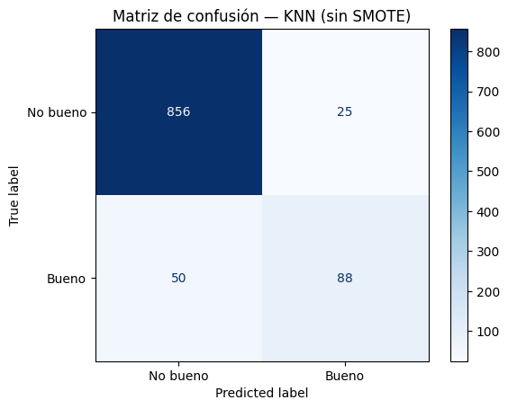

```python
y_pred_knn = best_knn.predict(X_train)
print(classification_report(y_train, y_pred_knn, target_names=['No bueno', 'Bueno'], zero_division=0))

ConfusionMatrixDisplay.from_predictions(y_train, y_pred_knn, display_labels=['No bueno', 'Bueno'], cmap='Blues')
plt.title('Matriz de confusión — KNN (sin SMOTE)')
plt.show()
```

Nótese que, hasta aquí, no hemos tocado `X_test` ni `y_test` en ningún momento, todo el proceso de selección de hiperparámetros ocurrió únicamente con validación cruzada sobre `X_train`. Vamos a mantener esa disciplina: construimos primero todos los modelos candidatos, y solo evaluamos contra el conjunto de prueba al final, para todos a la vez. Esto evita la tentación (aunque sea involuntaria) de ajustar un modelo después de haber visto el desempeño en test del anterior.

### 5.2 Modelado con KNN con SMOTE

Antes de entrenar, un punto metodológico que es fácil pasar por alto: **SMOTE debe aplicarse únicamente sobre los datos de entrenamiento, nunca sobre los de test**. Además, debe ser dentro de la validación cruzada, es decir, aplicarse *después* de cada partición de fold, no antes.

Si aplicáramos SMOTE sobre todo el conjunto de entrenamiento *antes* de hacer la validación cruzada (o peor, antes del split train/test), estaríamos generando puntos sintéticos interpolando entre vecinos que podrían terminar repartidos entre el fold de entrenamiento y el de validación (o entre train y test) de una misma iteración. Eso filtra información y el modelo estaría, en la práctica, validándose con puntos sintéticos derivados de datos que "ya vio", lo que infla artificialmente las métricas de validación sin que el modelo realmente generalice mejor.

`imblearn.pipeline.Pipeline` (a diferencia de `sklearn.pipeline.Pipeline`) resuelve esto automáticamente. Dentro de `GridSearchCV`, en cada fold, el paso de `SMOTE` se ajusta y aplica **solo** sobre los datos de entrenamiento de ese fold, el fold de validación nunca se toca.

> **Ejercicio:** antes de continuar, explica con tus propias palabras qué pasaría con las métricas de validación cruzada si aplicáramos `SMOTE().fit_resample(X_train, y_train)` una sola vez, *antes* de pasarle los datos a `GridSearchCV`, en lugar de incluir `SMOTE` como un paso del pipeline. ¿Las métricas se verían mejores o peores que las reales? ¿Por qué?

```python
smote_pipeline = ImbPipeline(steps=[
    ('scaler', StandardScaler()),
    ('smote', SMOTE(random_state=42)),
    ('knn', KNeighborsClassifier())
])

smote_grid = GridSearchCV(
    estimator=smote_pipeline,
    param_grid=param_grid,
    cv=cv,
    scoring='f1_macro',
    n_jobs=-1
)
smote_grid.fit(X_train, y_train)

print("Mejores hiperparámetros:", smote_grid.best_params_)
print(f"F1-macro en validación cruzada: {smote_grid.best_score_:.3f}")

best_smote = smote_grid.best_estimator_
```

```
Mejores hiperparámetros: {'knn__metric': 'minkowski', 'knn__n_neighbors': 3}
F1-macro en validación cruzada: 0.679
```

Ahora, veamos el rendimiento sobre train:

```
              precision    recall  f1-score   support

    No bueno       1.00      0.88      0.94       881
       Bueno       0.57      1.00      0.73       138

    accuracy                           0.90      1019
   macro avg       0.79      0.94      0.83      1019
weighted avg       0.94      0.90      0.91      1019
```

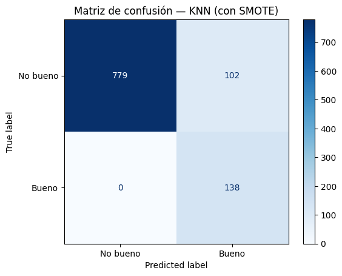

```python
y_pred_knn = best_smote.predict(X_train)
print(classification_report(y_train, y_pred_knn, target_names=['No bueno', 'Bueno'], zero_division=0))

ConfusionMatrixDisplay.from_predictions(y_train, y_pred_knn, display_labels=['No bueno', 'Bueno'], cmap='Blues')
plt.title('Matriz de confusión — KNN (con SMOTE)')
plt.show()
```

## 6. Evaluación y comparación

Con ambos modelos ya construidos (cada uno seleccionado solo con `X_train`), este es el único punto del notebook donde tocamos `X_test` — y lo hacemos una sola vez, para los dos modelos a la vez.

```python
y_pred_knn = best_knn.predict(X_test)
y_pred_smote = best_smote.predict(X_test)

print("KNN (sin SMOTE)")
print(classification_report(y_test, y_pred_knn, target_names=['No bueno', 'Bueno'], zero_division=0))
print("\nKNN + SMOTE")
print(classification_report(y_test, y_pred_smote, target_names=['No bueno', 'Bueno'], zero_division=0))
```

```
KNN (sin SMOTE)
              precision    recall  f1-score   support

    No bueno       0.91      0.93      0.92       294
       Bueno       0.48      0.43      0.45        46

    accuracy                           0.86       340
   macro avg       0.69      0.68      0.69       340
weighted avg       0.85      0.86      0.86       340


KNN + SMOTE
              precision    recall  f1-score   support

    No bueno       0.94      0.80      0.86       294
       Bueno       0.34      0.65      0.44        46

    accuracy                           0.78       340
   macro avg       0.64      0.73      0.65       340
weighted avg       0.86      0.78      0.81       340
```

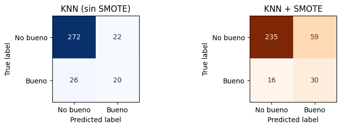

```python
fig, axes = plt.subplots(1, 2, figsize=(8, 2.5), constrained_layout=True)

ConfusionMatrixDisplay.from_predictions(
    y_test, y_pred_knn, display_labels=['No bueno', 'Bueno'], cmap='Blues', ax=axes[0], colorbar=False
)
axes[0].set_title('KNN (sin SMOTE)')

ConfusionMatrixDisplay.from_predictions(
    y_test, y_pred_smote, display_labels=['No bueno', 'Bueno'], cmap='Oranges', ax=axes[1], colorbar=False
)
axes[1].set_title('KNN + SMOTE')

plt.show()
```

Compara, lado a lado, el *recall* y la *precisión* de la clase "Bueno" en ambas matrices. Es común encontrar que SMOTE mejora notablemente el recall (el modelo detecta más vinos buenos) a cambio de una precisión menor (también se equivoca más, marcando como "bueno" algún vino que no lo es). Si esto ocurre, no es un error del modelo — es el trade-off esperado de SMOTE, y si conviene aceptarlo depende del costo relativo de cada tipo de error en el contexto de negocio.

Ahora, consolidamos las métricas de ambos modelos en una sola tabla y gráfico.

|  | F1-macro | Recall (Bueno) | Precisión (Bueno) |
| --- | --- | --- | --- |
| KNN (sin SMOTE) | 0.687 | 0.435 | 0.476 |
| KNN + SMOTE | 0.653 | 0.652 | 0.337 |

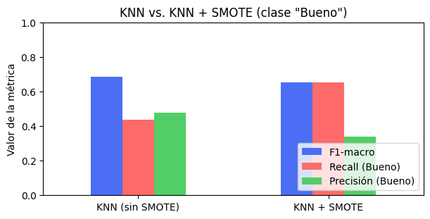

```python
def metricas_modelo(y_true, y_pred):
    return {
        'F1-macro': f1_score(y_true, y_pred, average='macro'),
        'Recall (Bueno)': recall_score(y_true, y_pred, pos_label=1),
        'Precisión (Bueno)': precision_score(y_true, y_pred, pos_label=1, zero_division=0),
    }

resultados = pd.DataFrame({
    'KNN (sin SMOTE)': metricas_modelo(y_test, y_pred_knn),
    'KNN + SMOTE': metricas_modelo(y_test, y_pred_smote),
}).T

display(resultados.round(3))

fig, ax = plt.subplots(figsize=(6, 3), constrained_layout=True)
resultados.plot(kind='bar', ax=ax, color=['#4C6EF5', '#FF6B6B', '#51CF66'])
ax.set(ylabel='Valor de la métrica', title='KNN vs. KNN + SMOTE (clase "Bueno")', ylim=(0, 1))
ax.legend(loc='lower right')
plt.xticks(rotation=0)
plt.show()
```

**Cómo se lee:** esta tabla resume el trade-off que discutimos arriba. Si en tu ejecución SMOTE mejoró el recall pero no necesariamente el F1-macro (o incluso lo bajó un poco), eso es un resultado legítimo y vale la pena discutirlo: **SMOTE no es una técnica que "siempre mejora todo"**. En general, mejora la capacidad de detectar la clase minoritaria, a cambio de más falsos positivos. En este caso, habría que preguntarse ¿qué es más costoso para una bodega, dejar pasar un vino bueno sin identificarlo (falso negativo), o enviar a revisión experta un vino que en realidad no era tan bueno (falso positivo)? La respuesta a esa pregunta de negocio es la que determina si vale la pena usar SMOTE aquí.

## 7. Cierre

En este notebook seguimos el ciclo completo de una solución de aprendizaje de máquina para un caso real con desbalance de clases.

**Ideas clave:**

- KNN se basa en distancias, por lo que las variables deben estar en escalas comparables para evitar que aquellas con valores de mayor magnitud dominen el cálculo.
- Con desbalance de clases, `accuracy` es una métrica engañosa; `f1_macro`, u otras métricas por clase, como `recall`, `precisión` o `balanced_accuracy`, permiten evaluar mejor el comportamiento del modelo en ambas clases.
- SMOTE **debe aplicarse únicamente sobre los datos de entrenamiento** y, durante la validación cruzada, debe formar parte del pipeline. Así se evita generar observaciones sintéticas utilizando información de los datos de validación o prueba.
- SMOTE no garantiza una mejora del modelo. Puede aumentar el `recall` de la clase minoritaria a costa de reducir la `precision`. Su conveniencia depende del costo que tengan los distintos tipos de error en el problema real.
- KNN se interpreta principalmente de forma local. Para comprender una predicción, pueden examinarse los vecinos más cercanos, sus distancias y sus clases. Esto permite identificar qué observaciones sustentaron la decisión y analizar casos en los que los vecinos muestran poca concordancia.

## 8. Ejercicios

1. Cambia el umbral de "buena calidad" de `quality >= 7` a `quality >= 6`. ¿Cómo cambia el desbalance de clases? ¿Cambian tus conclusiones sobre si SMOTE ayuda o no?
2. Repite el modelado usando el archivo de vino blanco (`winequality-white.csv`, mismo repositorio UCI, 4,898 muestras). ¿El desbalance y las conclusiones son similares?
3. En la Sección 5, ¿qué otras métricas (adicionales a F1-macro, recall y precisión) podrían ser relevantes para decidir si el modelo con o sin SMOTE es preferible en un contexto real de control de calidad?